Back to Article

###### Paper Randomisation

Download Source

# Randomise papers

Describes random selection of papers for inclusion in the review

Author

Saoirse Kelleher

Published

November 27, 2023

## Overview

As this review evolved, two samples of target papers were acquired from two distinct sampling protocols.

- The **First Sample** was acquired in October 2021 from Google Scholar. The first 100 hits for each of four search terms (‘dynamic occupancy model,’ ‘occupancy dynamics model,’ ‘multi-season occupancy model,’ and ‘stochastic patch occupancy model’, plus allowances for pluralisation) were downloaded. These were stratified by their query and year-window (2000-2005, 2006-2010, 2010-2015, and 2016-2021). A random sample of 25% of the strata *or* 5 papers, whichever was larger, was flagged for inclusion in the review, to be replaced from the same strata if inclusion criteria were not met.
- After reviewing this initial sample, the need for a **Second Sample** was identified as many of the papers included in the first did not represent our model of interest. This second, more narrowly targeted sample was drawn from papers citing MacKenzie et al. (2003), the original description of the model class which all subsequent implementations would be expected to cite. Papers were acquired via Web of Science in September 2023. The same 4 year-window strata were used here, with 15 papers randomly drawn from each strata. A fifth strata was added for 2022-2023, to capture the most recent papers on these models.

For transparency and reproducibility, the randomisation code is preserved in this document.

## First sample

The full list of papers acquired from the aforementioned queries is read into R, and each is assigned to a year-window.

```
In [1]:
```

```r
library("knitr")
library("tidyverse")
library("readxl")

set.seed(5378)

# From the excel review spreadsheet, read in only the identifying characteristics
first_idSheet <- readxl::read_xlsx("Spreadsheets/Stage1_Spreadsheet.xlsx",
                                     sheet = "Metadata", skip = 1) %>%
  # Drop rows prior to start of data
  slice(4:nrow(.)) %>%
  # Only need google search query and the ID reference
  select(Review_ID, Query = `Search terms`)

# Repeat with the study metadata
first_studyDataSheet <- readxl::read_xlsx("Spreadsheets/Stage1_Spreadsheet.xlsx",
                                    sheet = "Study data", skip = 1) %>%
  # Cut out non-data rows
  slice(4:nrow(.)) %>%
  # Only need year data and ID reference
  select(Review_ID, Title, Year)

# Merge paper queries and metadata
first_paperList <- full_join(first_idSheet, first_studyDataSheet,
                             by = "Review_ID") %>%
  # Exclude some non-query papers and add year periods to the rest
  # Drop empty rows, excluded, and incidental papers
  filter(!is.na(Query) & Query != "INCIDENTAL" & Year != "EXCLUDE") %>%
  # Break into time periods
  mutate(YearPeriod = case_when(Year %in% as.character(2000:2005) ~ "2000:2005",
                                Year %in% as.character(2006:2010) ~ "2006:2010",
                                Year %in% as.character(2011:2015) ~ "2011:2015",
                                Year %in% as.character(2016:2021) ~ "2016:2021"))

head(first_paperList) %>%
  kable()
```

| Review_ID | Query | Title | Year | YearPeriod |
| --- | --- | --- | --- | --- |
| 6 | Dynamic occupancy model | Single-visit dynamic occupancy models: an approach to account for imperfect detection with Atlas data | 2017 | 2016:2021 |
| 7 | Dynamic occupancy model | A dynamic occupancy model for interacting species with two spatial scales | 2020 | 2016:2021 |
| 8 | Dynamic occupancy model | A multistate dynamic occupancy model to estimate local colonization–extinction rates and patterns of co‐occurrence between two or more interacting species | 2019 | 2016:2021 |
| 9 | Dynamic occupancy model | Neural hierarchical models of ecological populations | 2019 | 2016:2021 |
| 11 | Dynamic occupancy model | Unravelling the drastic range retraction of an emblematic songbird of North Africa: potential threats to Afro-Palearctic migratory birds | 2017 | 2016:2021 |
| 12 | Dynamic occupancy model | Detecting dispersal: A spatial dynamic occupancy model to reliably quantify connectivity across heterogeneous conservation landscapes | 2021 | 2016:2021 |

A random number is then assigned to *all* papers. Papers are then ranked by number within their year-window/query strata. Papers in the top 5/25% (whichever was larger) were flagged to be read, and the rest were kept available for replacement of papers which may fail to meet inclusion criteria.

```
In [2]:
```

```r
# Randomly rank papers, then rank within the strata
first_rankedPapers <- first_paperList %>%
  # Add random ranks for all papers
  mutate(randRank = sample(x = 1:nrow(.), size = nrow(.))) %>%
  # Re-rank within strata
  group_by(Query, YearPeriod) %>%
  arrange(Query, YearPeriod, randRank) %>%
  mutate(GroupRank = row_number()) %>%
# Identify which papers qualify to be read
  group_by(Query, YearPeriod) %>%
  mutate(PercentRank =  GroupRank/max(GroupRank)) %>%
  mutate(ToRead = case_when(
    # If there are fewer than 5, read them all
    max(GroupRank) <= 5 ~ "YES",
    # If there are 20 or fewer, read the top 5
    max(GroupRank) <= 20 & GroupRank <= 5 ~ "YES",
    max(GroupRank) <= 20 & GroupRank >= 5 ~ "NO",
    # If there are 21 or more, read the top 25%
    max(GroupRank) >= 21 & PercentRank <= 0.25  ~ "YES",
    max(GroupRank) >= 21 & PercentRank > 0.25 ~ "NO")) %>%
  ungroup() %>%
  unite(col = Group, c(Query, YearPeriod)) %>%
  # Get Review_ID, GroupRank, and ToRead
  select(Review_ID, Title, Group, OverallRank = randRank, GroupRank, ToRead)

head(first_rankedPapers) %>%
  kable()
```

| Review_ID | Title | Group | OverallRank | GroupRank | ToRead |
| --- | --- | --- | --- | --- | --- |
| 51 | Dealing with uncertainty in amphibian and reptile population monitoring for conservation | Dynamic occupancy model_2006:2010 | 30 | 1 | YES |
| 69 | A BAYESIAN STATE-SPACE FORMULATION OF DYNAMIC OCCUPANCY MODELS | Dynamic occupancy model_2006:2010 | 82 | 2 | YES |
| 63 | Occurrence patterns of Black-backed Woodpeckers in green forest of the Sierra Nevada Mountains, California, USA. | Dynamic occupancy model_2011:2015 | 57 | 1 | YES |
| 50 | Individual and population-level responses of the Alabama beach mouse (Peromyscus polionotus ammobates) to environmental variation in space and time | Dynamic occupancy model_2011:2015 | 67 | 2 | YES |
| 59 | Effects of Urbanization on Occupancy of Stream Salamanders: Salamander Occupancy and Urbanization | Dynamic occupancy model_2011:2015 | 69 | 3 | YES |
| 39 | Coffee Agroforests Remain Beneficial for Neotropical Bird Community Conservation across Seasons | Dynamic occupancy model_2011:2015 | 70 | 4 | YES |

Incidental papers which were not ranked are returned to the dataframe, and the output is saved.

```
In [3]:
```

```r
first_unrankedPapers <- first_paperList %>%
  # Drop empty rows, excluded, and incidental papers
  filter(is.na(Query) | Query == "INCIDENTAL" | Year == "EXCLUDE") %>%
  mutate(ToRead = "NO", Group = "Unranked", GroupRank = "NA", OverallRank = "NA") %>%
  select(Review_ID, Title, Group, OverallRank, GroupRank, ToRead)

# Combine ranked and unranked papers
firstSample <- rbind(first_rankedPapers, first_unrankedPapers) %>%
  mutate(Review_ID = as.numeric(Review_ID)) %>%
  arrange(Review_ID) %>%
  mutate(Sample = "First")

# Write to disk
write_csv(firstSample, file = "Randomisation/FirstSampleRanks.csv")
```

## Second sample

The list of papers pulled from Web of Science is loaded in - 1184 papers are represented here. Year-windows are assigned here as in the **First Sample.**

```
In [4]:
```

```r
# Load query and extract relevant columns
second_Query <- readxl::read_xls("Queries/MacKenzie WOS/MacKenzie03.xls") %>%
  select(Review_ID, Title = `Article Title`, Year = `Publication Year`) %>%
  # Assign year period
  mutate(YearPeriod = case_when(Year %in% 2000:2005 ~ "2000:2005",
                                Year %in% 2006:2010 ~ "2006:2010",
                                Year %in% 2011:2015 ~ "2011:2015",
                                Year %in% 2016:2021 ~ "2016:2021",
                                Year %in% 2022:2023 ~ "2022:2023"))
head(second_Query) %>%
  kable()
```

| Review_ID | Title | Year | YearPeriod |
| --- | --- | --- | --- |
| 300 | Estimating the effects of land abandonment on mammal communities in the Karoo region of South Africa | 2023 | 2022:2023 |
| 301 | Occupancy of Bombus affinis (Hymenoptera: Apidae) in Minnesota is highest in developed areas when standardized surveys are employed | 2023 | 2022:2023 |
| 302 | Climate casualties or human disturbance? Shrinking distribution of the three large carnivores in the Greater Himalaya | 2023 | 2022:2023 |
| 303 | Nonparametric Identifiability in Species Distribution and Abundance Models: Why it Matters and How to Diagnose a Lack of it Using Simulation | 2023 | 2022:2023 |
| 304 | Variation in flight characteristics associated with entry by eagles into rotor-swept zones of wind turbines | 2023 | 2022:2023 |
| 305 | Passive acoustic monitoring using smartphones reveals an alarming gibbon decline in a protected area in the central Annamite Mountains, Vietnam | 2023 | 2022:2023 |

Papers are assigned a random number and ranked within their groups, and top-15 papers are flagged to be read. The output is saved for future reference.

```
In [5]:
```

```r
secondSample <- second_Query %>%
  # Add query flag to match with the first sample
  mutate(Query = "MacKenzie Cited") %>%
  # Add random ranks for all papers
  mutate(randRank = sample(x = 1:nrow(.), size = nrow(.))) %>%
  # Re-rank within strata
  group_by(Query, YearPeriod) %>%
  arrange(Query, YearPeriod, randRank) %>%
  mutate(GroupRank = row_number()) %>%
  mutate(ToRead = case_when(
    GroupRank <= 15 ~ "YES",
    GroupRank >15 ~ "NO")) %>%
  unite(col = Group, c(Query, YearPeriod)) %>%
  mutate(Sample = "Second") %>%
  # Get Review_ID, GroupRank, and ToRead
  select(Sample, Review_ID, Title, Group, OverallRank = randRank, GroupRank, ToRead)

write_csv(secondSample, "Randomisation/SecondSampleRanks.csv")

head(secondSample) %>%
  kable()
```

| Sample | Review_ID | Title | Group | OverallRank | GroupRank | ToRead |
| --- | --- | --- | --- | --- | --- | --- |
| Second | 1479 | Using counts to simultaneously estimate abundance and detection probabilities in a salamander community | MacKenzie Cited_2000:2005 | 18 | 1 | YES |
| Second | 1481 | Declining amphibian populations: The pitfalls of count data in the study of diversity, distributions, dynamics, and demography | MacKenzie Cited_2000:2005 | 37 | 2 | YES |
| Second | 1461 | Influence of the temporal resolution of data on the success of indicator species models of species richness across multiple taxonomic groups | MacKenzie Cited_2000:2005 | 78 | 3 | YES |
| Second | 1455 | Modeling spatial trends in estimated species richness using breeding bird survey data: A valuable tool in biodiversity assessment | MacKenzie Cited_2000:2005 | 204 | 4 | YES |
| Second | 1467 | A field-based evaluation of a presence-absence protocol for monitoring ecoregional-scale biodiversity | MacKenzie Cited_2000:2005 | 284 | 5 | YES |
| Second | 1469 | Monitoring distributions using call surveys: estimating site occupancy, detection probabilities and inferring absence | MacKenzie Cited_2000:2005 | 366 | 6 | YES |

## Sample summary

A basic representation of the two sample’s coverage is presented here. The data presented is from after randomisation, **not** after reviewing, and thus does not represent the final coverage of the review as some papers may be excluded.

### First sample categories

```
In [6]:
```

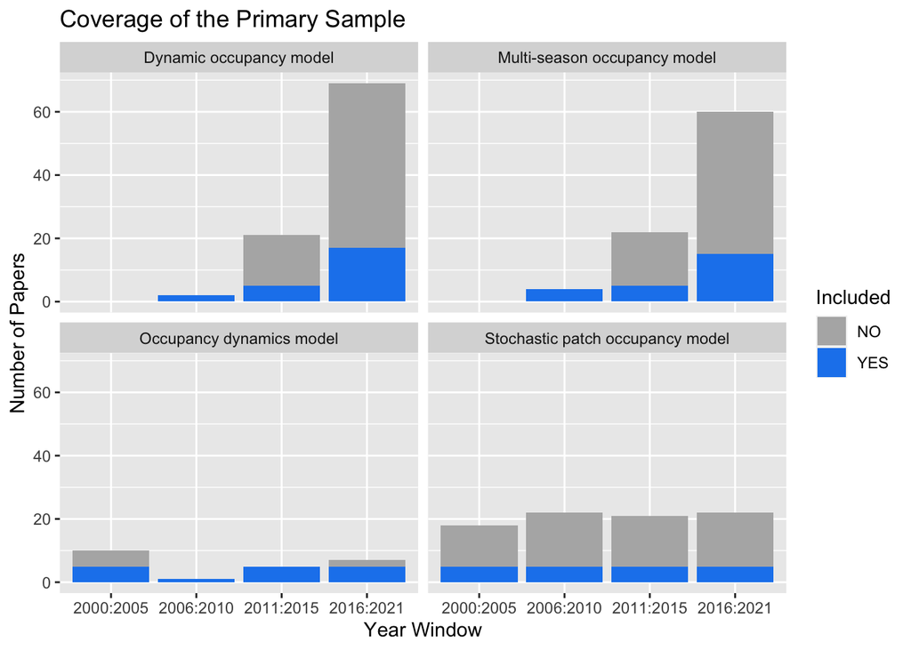

```r
firstSample %>%
  separate(Group, c("Query", "YearWindow"), sep = "_") %>%

  ggplot() +
  geom_bar(aes(x = YearWindow, fill = ToRead)) +
  scale_fill_manual(values = c("gray70", "dodgerblue2")) +
  facet_wrap(vars(Query), nrow = 2) +
  labs(title = "Coverage of the Primary Sample",
       y = "Number of Papers",
       x = "Year Window",
       fill = "Included")
```

### Second sample categories

```
In [7]:
```

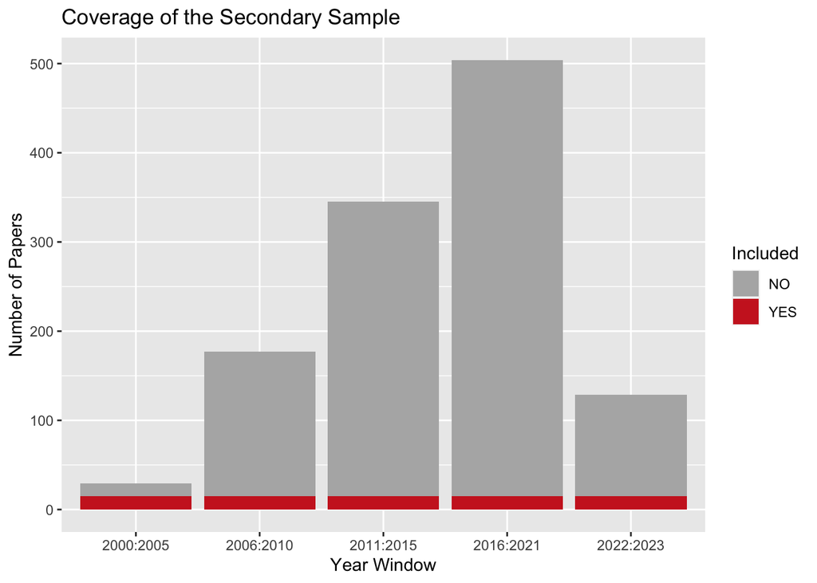

```r
secondSample %>%
  separate(Group, c("Query", "YearWindow"), sep = "_") %>%

  ggplot() +
  geom_bar(aes(x = YearWindow, fill = ToRead)) +
  scale_fill_manual(values = c("gray70", "firebrick3")) +
  labs(title = "Coverage of the Secondary Sample",
       y = "Number of Papers",
       x = "Year Window",
       fill = "Included")
```

### Combined sample

Adding the second sample improves coverage across the review period, particularly in the first two year-windows where fewer papers were included in the first sample.

```
In [8]:
```

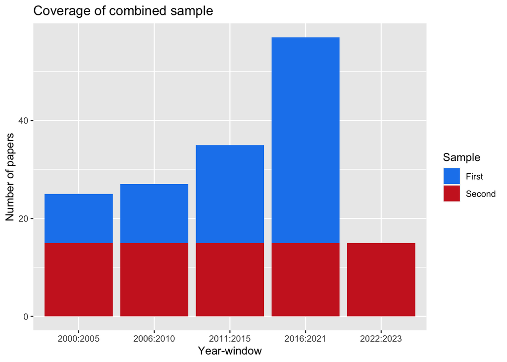

```r
rbind(firstSample, secondSample) %>%
  separate(Group, c("Query", "YearWindow"), sep = "_") %>%
  filter(ToRead == "YES") %>%

  ggplot() +
  geom_bar(aes(x = YearWindow, fill = Sample)) +
  scale_fill_manual(values = c("dodgerblue2", "firebrick3")) +
  labs(title = "Coverage of combined sample",
       y = "Number of papers",
       x = "Year-window")
```

## References

MacKenzie, Darryl I., James D. Nichols, James E. Hines, Melinda G. Knutson, and Alan B. Franklin. 2003. “ESTIMATING SITE OCCUPANCY, COLONIZATION, AND LOCAL EXTINCTION WHEN A SPECIES IS DETECTED IMPERFECTLY.” *Ecology* 84 (8): 2200–2207. https://doi.org/10.1890/02-3090.